# Spanish Electricity

With a dataset taking the price of the electricty during 24h over different days, months and years :

- Let's study what is the cheapest moment to use electricity with the mean for the hours, days of the week and both combined.
- To confirm the findings, I will do a statistic analysis to see if our data follow a certain pattern and study the distribution.

**Tools**

Excel :

-Pivot Table, Pivot Chart, Xlookup function, Min/Max function

Python libraries :  
-`BeautifulSoup` from `bs4`  
-`csv`  
-`time`  
-`datetime`  
-`urllib.parse`  
-`webdriver` from `selenium`  
-`By` from `selenium.webdriver.common.by`  
-`WebDriverWait` from `selenium.webdriver.support.ui`  
-`expected_conditions` from `selenium.webdriver.support`  
-`pandas` as `pd`  
-`seaborn` as `sns`  
-`matplotlib.pyplot` as `plt`  
-`statsmodels.api` as `sm`  
-`ols` from `statsmodels.formula.api`  
-`pairwise_tukeyhsd` from `statsmodels.stats.multicomp`

Analysis :  
-`count`  
-`mean`  
-`min`  
-`25% Quartile`  
-`50% Quartile`  
-`75% Quartile`  
-`max`  
-`Standard Deviation`  
-Heatmap to analyze the impact of Hour of the Day and Day of the Week on Price to see the trends and patterns in the data  
-Correlation coefficient to calculate the correlation between price and hour of the day and between price and day of the week  
-Two-way ANOVA model  
-Tukey's HSD (honestly significant difference) test to compare the mean price of each hour of the day and day of the week to determine which hours and days have significantly different mean prices.

**Steps**

1.Get the data :  
-Webscraping (read disclaimer) using Python and `BeautifulSoup`  
-CSV report using Excel

2.First analysis on Excel using Pivot Table, Pivot Chart, Xlookup function, and Min/Max function

3.Distribution and correlation analysis using Python :  
-Calculate `count`, `mean`, `min`, `25% Quartile`, `50% Quartile`, `75% Quartile`, `max`, and `Standard Deviation`  
-Create a heatmap to analyze the impact of Hour of the Day and Day of the Week on Price to see the trends and patterns in the data  
-Calculate the correlation coefficient to determine the correlation between price and hour of the day and between price and day of the week  
-Use a Two-way ANOVA model to analyze the impact of Hour of the Day and Day of the Week on Price  
-Use Tukey's HSD (honestly significant difference) test to compare the mean price of each hour of the day and day of the week to determine which hours and days have significantly different mean prices.

# Conclusion of the study

- From the first analysis on Excel, it seems that the best moment to use electricity is on Sunday between 15h and 16h with an average of 0,145522626 euro/kWh.

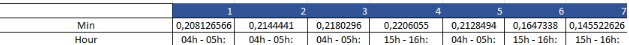

- Based on the further analysis, it appears that both Hour of the Day and Day of the Week have a significant impact on the Price.

The correlation between Price and Hour of the Day is positive but relatively weak (0.150), indicating that as the Hour of the Day increases, the Price tends to increase slightly. On the other hand, the correlation between Price and Day of the Week is negative and also weak (-0.179), indicating that as the Day of the Week increases (from Monday to Sunday), the Price tends to decrease slightly.

The ANOVA test results show that both Hour of the Day and Day of the Week have a significant effect on the Price, as evidenced by the very low p-values for both variables (p < 0.001). The interaction between Hour of the Day and Day of the Week also has a significant effect on the Price (p < 0.001).

The Tukey's HSD test results suggest that certain hours of the day have significantly different mean prices compared to others. Specifically, the hours between 7h-8h, 9h-11h, 13h-16h, 17h-22h have significantly different mean prices compared to other hours.

Similarly, certain days of the week also have significantly different mean prices compared to others. Specifically, the weekends (Saturday and Sunday) have significantly different mean prices compared to weekdays (Monday to Friday).

Overall, it can be concluded that both Hour of the Day and Day of the Week have a significant impact on the Price, and certain hours and days have significantly different mean prices compared to others. Therefore, it is recommended to consider both Hour of the Day and Day of the Week when predicting or modeling Price.

=> The best day and period to use electricty : Sunday between 15h and 16h with an average of 0,145522626 euro/kWh.

# STEP 1 : get the data (1/2) -> Webscraping (read disclaimer).

Disclaimer : The information on the website is public, the code works and does not overcharge the server. However, I checked in the "terms of use" of the website to see if webscraping was allowed. It is not very clear and a section stipulates that for any question, an e-mail should be adressed to the "datos" service. Which is what I did but I have not received an answer. Therefore, for precaution, I HAVE NOT USED THE DATA from the webscraping for this project. I just let the code here to say it was part of my approach to solve the problem.

- On the website tarifaluzhora.es, there is no report that could be downloaded as a CVS for instance and treat the data. Only the current tab can be used.
- There is an option though to change the date and get the prices for the selected day. At the URL level, the only thing changing is for the date with the day, month and year. From this, it was easy to use a web scraping script to change the date in the URL and take the tab containing the data.

METHOD :

I used the selenium librairy to simulate actions on the browser and use webscraping.

Basically, it just does what a human would do but automatically : Open the tab with the correct date in the URL -> Look at the HTML code to find the table and get each element from this location 'div', {'class': 'col-xs-9'} -> Put the data in a CSV file.

```python
!pip install selenium
```

```python
!pip install webdriver-manager
```

```
  Using cached webdriver_manager-3.8.6-py2.py3-none-any.whl (27 kB)
  Using cached python_dotenv-1.0.0-py3-none-any.whl (19 kB)
```

```python
from bs4 import BeautifulSoup
import csv
import time
import datetime
import urllib.parse
from selenium import webdriver
from selenium.webdriver.common.by import By
from selenium.webdriver.support.ui import WebDriverWait
from selenium.webdriver.support import expected_conditions as EC
```

```python
# Define the start and end dates
start_date = datetime.date(2021, 6, 1)
end_date = datetime.date(2023, 5, 1)

# Set up the webdriver and wait for the page to load
driver = webdriver.Chrome()
wait = WebDriverWait(driver, 10)

# Iterate over each day between the start and end dates
current_date = start_date
while current_date <= end_date:

    # Format the date as dd/mm/yyyy
    date_str = current_date.strftime("%d/%m/%Y")

    # Encode the date as URL parameters
    params = urllib.parse.urlencode({'tarifa': 'pcb', 'fecha': date_str})

    # Build the URL
    url = 'https://tarifaluzhora.es/?' + params

    driver.get(url)

    # Get the HTML code of the website and parse it with BeautifulSoup
    html = driver.page_source
    soup = BeautifulSoup(html, 'html.parser')

    # Find the element you want to extract data from
    hour_prices = soup.find('div', {'id': 'hour_prices'})

    # Extract the price and hour data for each value in 'class': 'col-xs-9'
    prices = []
    hours = []
    for row in hour_prices.find_all('div', {'class': 'col-xs-9'}):
        hour = row.find('span', {'itemprop': 'description'}).text.strip()
        price = row.find('span', {'itemprop': 'price'}).text.strip()
        hours.append(hour)
        prices.append(price)

    # Write the data to a CSV file
    with open('hour_prices.csv', 'a', newline='') as csvfile:
        writer = csv.writer(csvfile)
        # Don't write the header row if the file already exists
        if csvfile.tell() == 0:
            writer.writerow(['Hour', 'Price', 'Date'])
        for hour, price in zip(hours, prices):
            # Write a row with the hour, price, and current date
            writer.writerow([hour, price, current_date])



    # Move to the next day
    current_date += datetime.timedelta(days=1)
    time.sleep(5) #let a delay not to overwhelmed the server




# Close the Selenium webdriver
driver.quit()
```

# STEP 1 : Get the data (2/2) -> CSV report

After not seeing an answer to know if I could get the data with a Python Script, I have looked for a website with an API or extract option. I have found this one : https://www.esios.ree.es/en/.

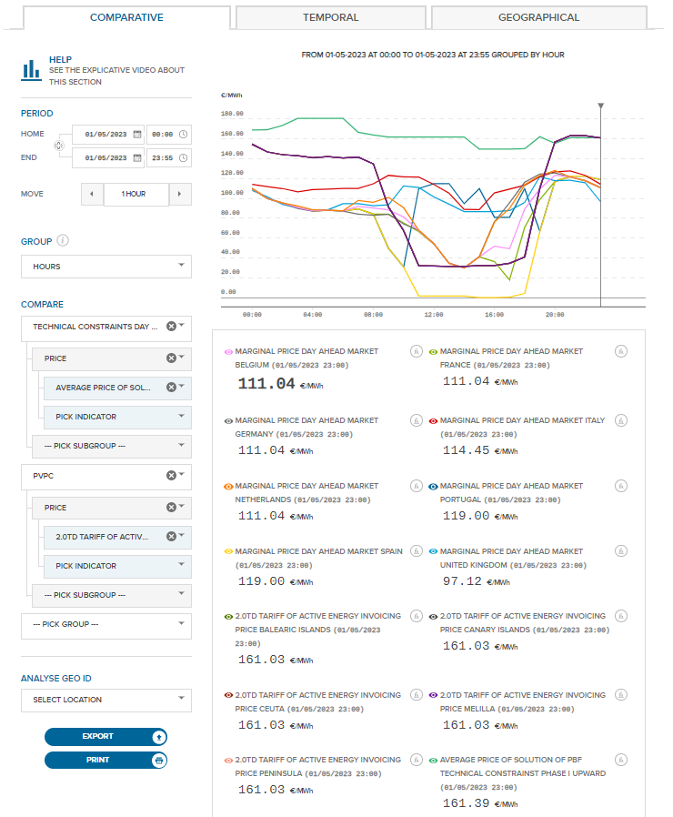

As a result I could get a CSV file with the same data as the first Website. I opened the file in excel to get a first glance of the data as a table.

DATASET :

- (16753 ROWS, 3 COLUMNS : Hour, Price in €/kWh, Date dd/mm/yyyy)
- Data from the 1st of June 2021 to the 1st of May 2023

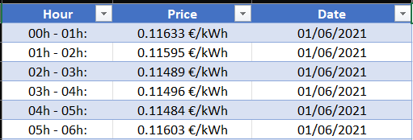

**------------------------------------------------------------------------------------------------------------------------------------------------------------------------------------------------------------------**

# STEP 2 : First analysis on Excel

The dataset is small enough to do a first analysis on Excel.

Let's first observe what the data look like with a curve.

The curve (average price regarding the hour, day and year) seems to have a shape with certain patterns.

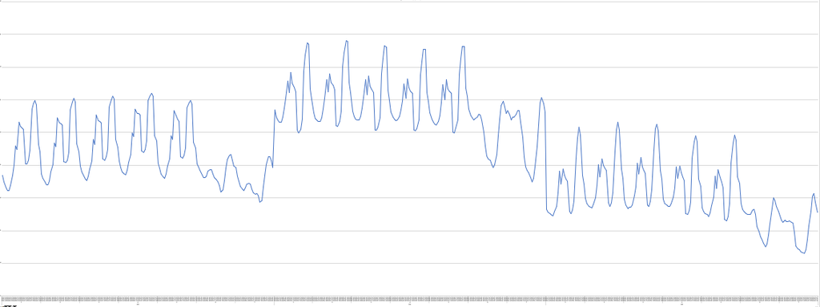

Let's zoom to see the axis. The pattern seems to repeat itself over each day regarding the hours. The curve for 2022 seems higher than 2021 and 2023, this is likely to be due to the war in Ukraine but I will not study it for this project.What matters in the first place, is to that there is **no randomness in the distribution of the values.**

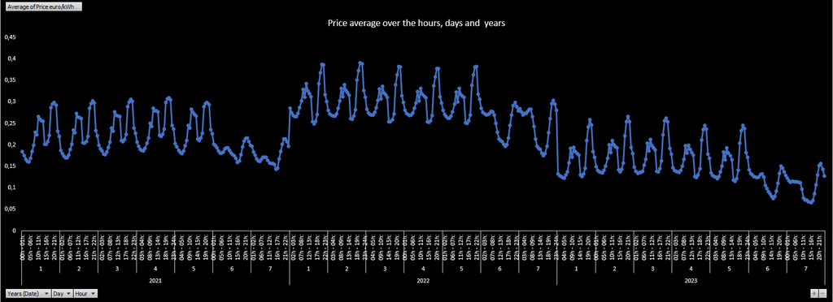

**1) What is the best hour to have the cheapest price over the entire dataset ?**

With a pivot table, let's look at the "Hour" as indicator and the average price (sorted desc). In average, the best Hour to use electricty and pay less is 15h-16h. The worst one is 20h-21h.

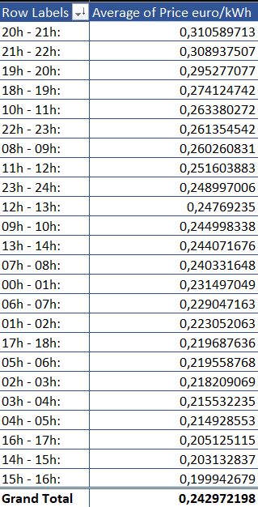

**2) Is the information still true if we look at the day level ?**

This time, let's do a pivot a table, filter by day and average price. Let's create another table where the minimumand maximum average price per hour will be returned for each day, as well as the corresponding hour (xlookup function).

We can observe here that the previous answer it's not the case for all the days.

So, if we want to pay less each day, we should in theory look at each day separately and not the total average.

If we do not want to look at per day and want to follow the general average per hour, the difference is not dramatically significant

(3% loss maximum -> formula : 1-Theorical minimum price/Real price) if we want to track the minimum.

**=> For any reason, if we cannot look at the prices each day on the website, targeting the time frame 15h-16h is a good strategy to save money when using electricty.**

We can also see in this that the cheapest day is on Sunday in average between 15h and 16h.

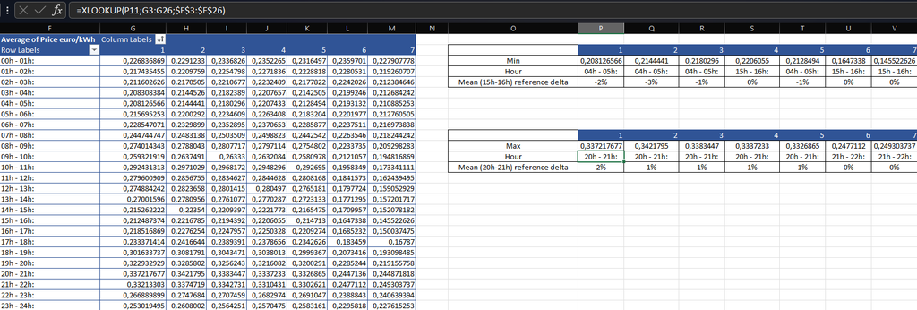

**------------------------------------------------------------------------------------------------------------------------------------------------------------------------------------------------------------------**

# STEP 3 : Distribution and Correlation of the data

**How much can we be confident in what we have found ?**

- The shape of the curve (prices over the time Hour per day of the week over the years) give a first glance to see that the data seem to follow a pattern.
- We have identified the cheapest prices regarding the hour and see if there was a great difference if we compare for each day of the week.

But is this enough to be sure that the prices are really impacted by the hour and the day of the week ?

Indeed, if we look at the mean of the hours and the days of the week, it is pretty hard to say if the differences really matter because the mean are similar. Furthermore, the disbribution of the values around each means seems to quite even and not very great.

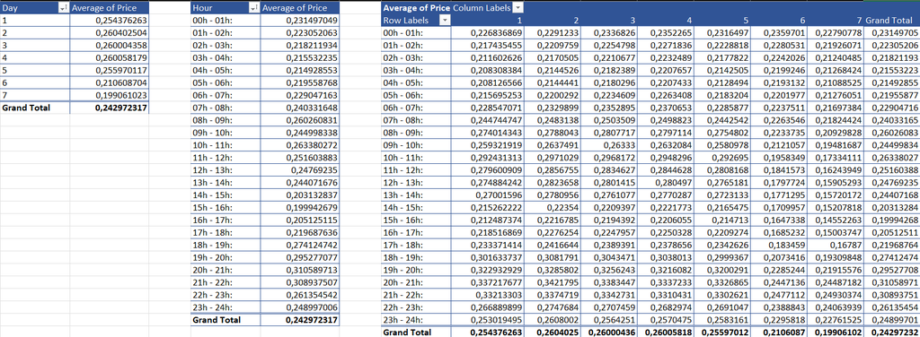

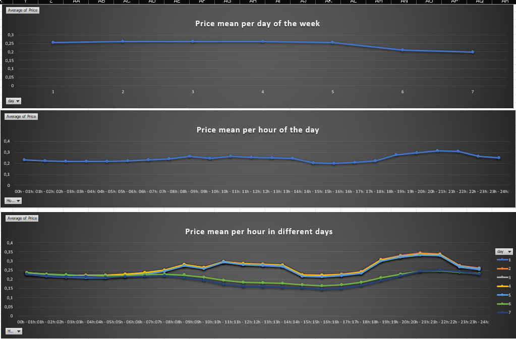

Let's do 2 things :

- Study how the values are distributed to see whether the differences are really significant for the different factors
- What factor between the hour and the day have the most impact.

```python
#Let's add a dataFrame with the values
import pandas as pd

# Read the Excel file into a DataFrame
df = pd.read_excel('pricespython.xlsx')

# extract the first two digits of the "Hour" column
df['Hour'] = df['Hour'].str[:2].astype(int)

# convert the "Date" column to datetime format
df['Date'] = pd.to_datetime(df['Date'])

# Print the first rows of the DataFrame to verify that the data was loaded correctly
print(df.head())
```

```
   Hour    Price       Date
0     0  0.11633 2021-06-01
1     1  0.11595 2021-06-01
2     2  0.11489 2021-06-01
3     3  0.11496 2021-06-01
4     4  0.11484 2021-06-01
```

```python
#Let's group the values by hour and by day to have the same tables as in Excel

df['DayofWeek'] = df['Date'].dt.dayofweek + 1


hourly_prices = df.groupby('Hour')['Price'].mean()

weekday_prices = df.groupby(['DayofWeek'])['Price'].mean()

hourly_by_weekday = df.groupby(['Hour', 'DayofWeek'])['Price'].mean()
```

```python
hourly_by_weekday.describe()
```

```
count    168.000000
mean       0.242926
std        0.043601
min        0.145523
25%        0.218187
50%        0.229353
75%        0.274797
max        0.342180
Name: Price, dtype: float64
```

```python
hourly_prices.describe()
```

```
count    24.000000
mean      0.242972
std       0.031392
min       0.199943
25%       0.219221
50%       0.242202
75%       0.260534
max       0.310590
Name: Price, dtype: float64
```

```python
weekday_prices.describe()
```

```
count    7.000000
mean     0.242926
std      0.026333
min      0.199060
25%      0.232492
50%      0.255970
75%      0.260031
max      0.260403
Name: Price, dtype: float64
```

The standard deviations of the three groups are quite different.

The hourly_by_weekday group has the largest standard deviation (0.0436), indicating that the hourly prices fluctuate quite a bit within each day of the week.

The hourly_prices group has a smaller standard deviation (0.0314), indicating that the hourly prices across all days are more stable compared to within each day of the week.

The weekday_prices group has the smallest standard deviation (0.0263), indicating that the average prices across all weekdays are relatively consistent.

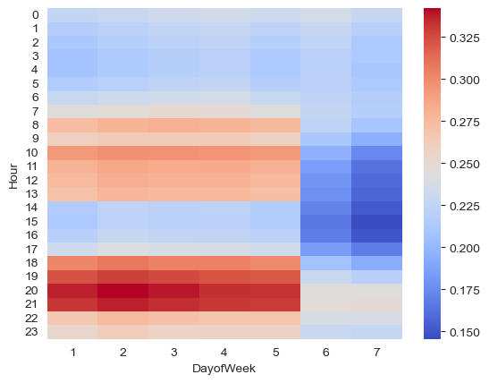

```python
#Let's visualize what we have on excel to see the distribution of the values with a heatmap

import seaborn as sns
import matplotlib.pyplot as plt

# reshape the series into a dataframe with columns for hour, day of week, and mean price
df_heatmap = hourly_by_weekday.unstack(level=-1)

# plot the heatmap
sns.heatmap(df_heatmap, cmap='coolwarm')
plt.show()
```

```python
# Calculate the correlation between price and hour of the day
hourly_corr = df['Price'].corr(df['Hour'])

# Calculate the correlation between price and day of the week
weekday_corr = df['Price'].corr(df['DayofWeek'])

print(f"Correlation between price and hour of the day: {hourly_corr:.3f}")
print(f"Correlation between price and day of the week: {weekday_corr:.3f}")
```

```
Correlation between price and hour of the day: 0.150
Correlation between price and day of the week: -0.179
```

These correlation coefficients suggest a weak positive correlation (0.150) between the price and the hour of the day, and a weak negative correlation (-0.179) between the price and the day of the week. However, keep in mind that correlation does not necessarily imply causation, and further analysis may be needed to establish any causal relationships between these variables.

```python
import statsmodels.api as sm
from statsmodels.formula.api import ols



# Fit the two-way ANOVA model
model = ols('Price ~ C(Hour) + C(DayofWeek) + C(Hour):C(DayofWeek)', data=df).fit()

# Print the ANOVA table
print(sm.stats.anova_lm(model, typ=2))
```

```
                          sum_sq       df           F         PR(>F)
C(Hour)                15.820158     23.0   70.614092  4.003343e-314
C(DayofWeek)            9.935801      6.0  170.004356  1.297147e-210
C(Hour):C(DayofWeek)    5.878923    138.0    4.373479   4.700061e-58
Residual              161.540299  16584.0         NaN            NaN
```

The ANOVA shows that both hour of the day and day of the week have a significant impact on the price. However, the interaction between the hour of the day and day of the week has a smaller impact on the price compared to the individual effects of each variable. This suggests that while the hour of the day and day of the week are both important factors, they have mostly independent effects on the price.

One way to determine the specific hours of the day and days of the week that have the most impact on Price is to conduct post-hoc tests or follow-up analyses.

We will perform Tukey's HSD (honestly significant difference) test to compare the mean price of each hour of the day and day of the week to determine which hours and days have significantly different mean prices.

```python
from statsmodels.stats.multicomp import pairwise_tukeyhsd

# Conduct Tukey's HSD test for Hour of the Day
tukey_hour = pairwise_tukeyhsd(df['Price'], df['Hour'])


# Conduct Tukey's HSD test for Hour of the Day
tukey_hour = pairwise_tukeyhsd(df['Price'], df['Hour'])

significant_hour_pairs = [(i, j) for (i, j, reject) in zip(tukey_hour.groupsunique, tukey_hour.groupsunique[1:], tukey_hour.reject) if reject]

significant_hour_pairs
```

```
[(7, 8),
 (9, 10),
 (10, 11),
 (13, 14),
 (14, 15),
 (15, 16),
 (17, 18),
 (18, 19),
 (19, 20),
 (20, 21),
 (21, 22)]
```

That output represents the pairs of groups where the null hypothesis of equal means has been rejected based on the Tukey's HSD test for Hour of the Day. These pairs have a significant difference between their means.

For example, (7, 8) means that the mean prices of hour 7 and hour 8 are significantly different from each other.

Similarly, (9, 10) means that the mean prices of hour 9 and hour 10 are significantly different from each other. And so on.

You can conclude that these pairs have a significant difference in mean prices based on the Tukey's HSD test.

```python
# Conduct Tukey's HSD test for Dayofweek
tukey_dayofweek = pairwise_tukeyhsd(df['Price'], df['DayofWeek'])

# Extract the pairs where reject=True
significant_dayofweek_pairs = [(i, j) for (i, j, reject) in zip(tukey_dayofweek.groupsunique, tukey_dayofweek.groupsunique[1:], tukey_dayofweek.reject) if reject]

print(significant_dayofweek_pairs)
```

```
[(5, 6), (6, 7)]
```

The Tukey test suggests that there is a significant difference in the mean price between days 5 and 6, and between days 6 and 7.